# Natural Disaster Data

## Synopsis

This analysis looks at the NOAA storm data to answer the questons:

- which events cause the most injuries and fatalities
- which events cause the most crop and propterty damages

```r
library(plyr)
```

Reading the data and subsetting to only include necessary columns.

```r
gollums<- c('EVTYPE','FATALITIES','INJURIES','PROPDMG','PROPDMGEXP','CROPDMG','CROPDMGEXP')
sd<- read.csv(bzfile('repdata-data-StormData.csv.bz2'),stringsAsFactors = FALSE)
sd<- sd[, gollums]
sd<- subset(sd, FATALITIES!=0 | INJURIES != 0 | PROPDMG != 0 | CROPDMG !=0)
```

Looking at the different exponents for the dollar amounts.The pdf states the usage of K,M, and B, but for the Property data there are over 10,000 records with no indicator (assume exponent 1) and for the crop data more than 50% of the records have no indicator (assume exponent 1). So I assumed 1 as exponent for any observation that was not H, K, M or B.That is default for value of damage is property damage or crop damage dollar amount.

```r
count(sd$PROPDMGEXP)
```

```
##    x   freq
## 1     11585
## 2  -      1
## 3  +      5
## 4  0    210
## 5  2      1
## 6  3      1
## 7  4      4
## 8  5     18
## 9  6      3
## 10 7      3
## 11 B     40
## 12 h      1
## 13 H      6
## 14 K 231428
## 15 m      7
## 16 M  11320
```

```r
count(sd$CROPDMGEXP)
```

```
##   x   freq
## 1   152664
## 2 ?      6
## 3 0     17
## 4 B      7
## 5 k     21
## 6 K  99932
## 7 m      1
## 8 M   1985
```

## Data Processsing

```r
sd$PROPDMGEXP<-toupper(sd$PROPDMGEXP)
sd$CROPDMGEXP<-toupper(sd$CROPDMGEXP)
```

Convert to actual dollar amount for aggregation since there is no consistent data entry for the exponents this leads to different results for different ways. Calculating for exponents H,K,M and B and leaving other numbers as is.

```r
sd<- mutate(sd, PROPAmt = ifelse(sd$PROPDMGEXP=='H',sd$PROPDMG*100,ifelse(sd$PROPDMGEXP=='K', sd$PROPDMG*10^3, ifelse(sd$PROPDMGEXP=='M', sd$PROPDMG*10^6, ifelse(sd$PROPDMGEXP=='B', sd$PROPDMG*10^9,sd$PROPDMG)))))
```

```r
sd<- mutate(sd, CROPAmt = ifelse(sd$CROPDMGEXP=='H',sd$CROPDMG*100, ifelse(sd$CROPDMGEXP=='K', sd$CROPDMG*10^3, ifelse(sd$CROPDMGEXP=='M', sd$CROPDMG*10^6, ifelse(sd$CROPDMGEXP=='B', sd$CROPDMG*10^9,sd$CROPDMG)))))
```

Since no more than 3 graphs, injuries and fatalities are combined

```r
sd<- mutate(sd, Tot_num = sd$FATALITIES + sd$INJURIES)
```

Aggregate amounts for injuries, fatalitites and property and crop damage amounts

```r
hurt<- aggregate(sd$Tot_num~sd$EVTYPE, data=sd, FUN=sum)
cropdmg<- aggregate(sd$CROPAmt~sd$EVTYPE, data=sd, FUN=sum)
propdmg<- aggregate(sd$PROPAmt~sd$EVTYPE, data=sd, FUN=sum)
```

Rename columns

```r
names(hurt)<- c('event','number')
names(cropdmg)<- c('event','amount')
names(propdmg)<- c('event','amount')
```

Take top 10 only

```r
hurt<- hurt[order(-hurt$number),][1:10,]
cropdmg<- cropdmg[order(-cropdmg$amount),][1:10,]
propdmg<- propdmg[order(-propdmg$amount),][1:10,]
```

There are a lot more wind related events than any other event. Grouping of some of the event types (TSTM Wind, Thunderstorm Wind, High Wind, Strong Wind, WIND, Wind) should probably be together. This shows about 3 events for thunderstorm wind which should probably be one category.

```r
event_type<- count(sd$EVTYPE)
event_type<- event_type[order(-event_type$freq),][1:10,]
event_type
```

```
##                      x  freq
## 423          TSTM WIND 63234
## 364  THUNDERSTORM WIND 43655
## 407            TORNADO 39944
## 134               HAIL 26130
## 73         FLASH FLOOD 20967
## 258          LIGHTNING 13293
## 381 THUNDERSTORM WINDS 12086
## 86               FLOOD 10175
## 200          HIGH WIND  5522
## 353        STRONG WIND  3370
```

## Results

### Injuries and Fatalities Plot

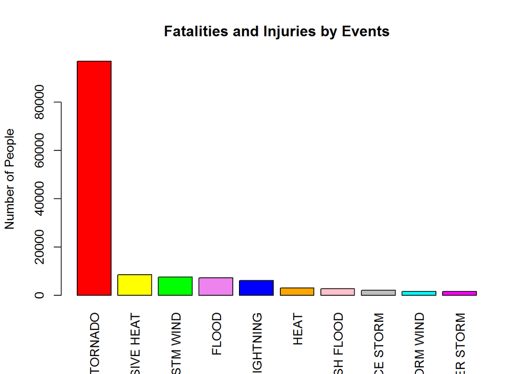

```r
colors<- c('red', 'yellow','green','violet', 'blue','orange','pink', 'grey','cyan', 'magenta')
barplot(hurt$number, col=colors, names.arg = hurt$event, main='Fatalities and Injuries by Events', ylab='Number of People',las=3)
```

```r
hurt
```

```
##                 event number
## 407           TORNADO  96979
## 61     EXCESSIVE HEAT   8428
## 423         TSTM WIND   7461
## 86              FLOOD   7259
## 258         LIGHTNING   6046
## 151              HEAT   3037
## 73        FLASH FLOOD   2755
## 238         ICE STORM   2064
## 364 THUNDERSTORM WIND   1621
## 481      WINTER STORM   1527
```

### Damage plot

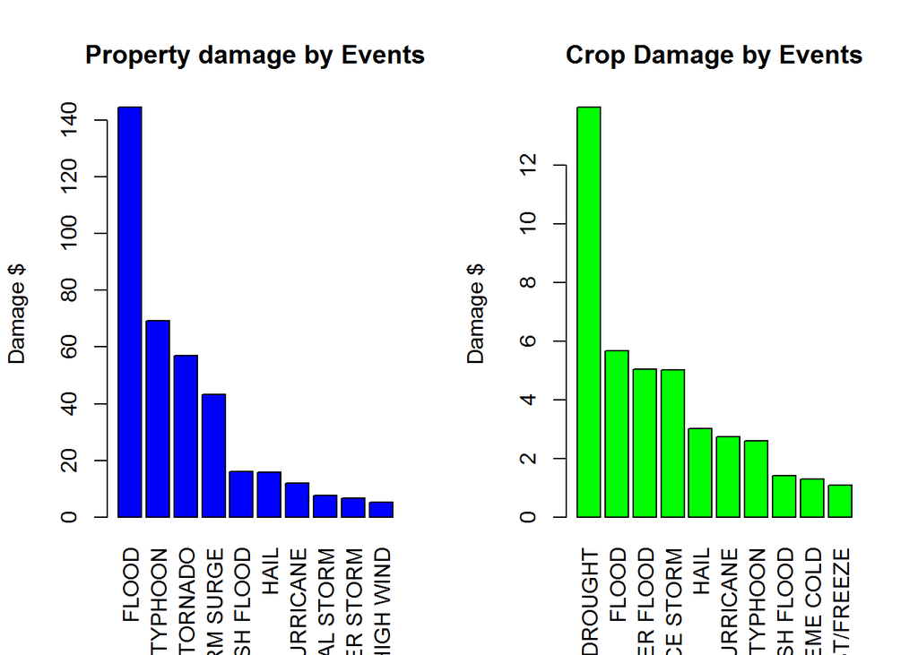

```r
par(mfrow=c(1,2))
barplot(propdmg$amount / 10^9, col='blue', names.arg = propdmg$event, main='Property damage by Events',ylab='Damage $',las=3)
barplot(cropdmg$amount /10^9, col='green', names.arg = cropdmg$event, main='Crop Damage by Events',ylab='Damage $',las=3)
```

```r
par(mfrow=c(1,1))
```

Results in numbers: And if you live in an area with Tornadoes (Florida) a storm cellar may be a good investment.Trailer park, not so much.

```r
propdmg
```

```
##                 event       amount
## 86              FLOOD 144657709807
## 224 HURRICANE/TYPHOON  69305840000
## 407           TORNADO  56937160779
## 350       STORM SURGE  43323536000
## 73        FLASH FLOOD  16140812067
## 134              HAIL  15732267543
## 215         HURRICANE  11868319010
## 417    TROPICAL STORM   7703890550
## 481      WINTER STORM   6688497251
## 200         HIGH WIND   5270046295
```

```r
cropdmg
```

```
##                 event      amount
## 49            DROUGHT 13972566000
## 86              FLOOD  5661968450
## 310       RIVER FLOOD  5029459000
## 238         ICE STORM  5022113500
## 134              HAIL  3025954473
## 215         HURRICANE  2741910000
## 224 HURRICANE/TYPHOON  2607872800
## 73        FLASH FLOOD  1421317100
## 67       EXTREME COLD  1292973000
## 114      FROST/FREEZE  1094086000
```